# Proyecto 2 Entrega 4

Andre Jo 22199

2025-03-21

```r
library(GGally)
library(dplyr)
library(tidyverse)
library(class)
library(ggplot2)
library(caret)
```

Debido a que los datos que observamos, tienen datos faltantes, se realiza un la media y el promedio de los datos para rellenar valores faltantes.

```r
head(summary(datos))
```

```
##        Id         MSSubClass       MSZoning          LotFrontage
##  Min.   :1461   Min.   : 20.00   Length:1459        Min.   : 21.00
##  1st Qu.:1826   1st Qu.: 20.00   Class :character   1st Qu.: 60.00
##  Median :2190   Median : 50.00   Mode  :character   Median : 67.00
##  Mean   :2190   Mean   : 57.38                      Mean   : 68.33
##  3rd Qu.:2554   3rd Qu.: 70.00                      3rd Qu.: 78.00
##  Max.   :2919   Max.   :190.00                      Max.   :200.00
##     LotArea         Street             Alley             LotShape
##  Min.   : 1470   Length:1459        Length:1459        Length:1459
##  1st Qu.: 7391   Class :character   Class :character   Class :character
##  Median : 9399   Mode  :character   Mode  :character   Mode  :character
##  Mean   : 9819
##  3rd Qu.:11518
##  Max.   :56600
##  LandContour         Utilities          LotConfig          LandSlope
##  Length:1459        Length:1459        Length:1459        Length:1459
##  Class :character   Class :character   Class :character   Class :character
##  Mode  :character   Mode  :character   Mode  :character   Mode  :character
##
##
##
##  Neighborhood        Condition1         Condition2          BldgType
##  Length:1459        Length:1459        Length:1459        Length:1459
##  Class :character   Class :character   Class :character   Class :character
##  Mode  :character   Mode  :character   Mode  :character   Mode  :character
##
##
##
##   HouseStyle         OverallQual      OverallCond      YearBuilt
##  Length:1459        Min.   : 1.000   Min.   :1.000   Min.   :1879
##  Class :character   1st Qu.: 5.000   1st Qu.:5.000   1st Qu.:1953
##  Mode  :character   Median : 6.000   Median :5.000   Median :1973
##                     Mean   : 6.079   Mean   :5.554   Mean   :1971
##                     3rd Qu.: 7.000   3rd Qu.:6.000   3rd Qu.:2001
##                     Max.   :10.000   Max.   :9.000   Max.   :2010
##   YearRemodAdd   RoofStyle           RoofMatl         Exterior1st
##  Min.   :1950   Length:1459        Length:1459        Length:1459
##  1st Qu.:1963   Class :character   Class :character   Class :character
##  Median :1992   Mode  :character   Mode  :character   Mode  :character
##  Mean   :1984
```

[output cut: 92 more lines]

```
##                                                           Max.   :17000.00
##      MoSold           YrSold       SaleType         SaleCondition
##  Min.   : 1.000   Min.   :2006   Length:1459        Length:1459
##  1st Qu.: 4.000   1st Qu.:2007   Class :character   Class :character
##  Median : 6.000   Median :2008   Mode  :character   Mode  :character
##  Mean   : 6.104   Mean   :2008
##  3rd Qu.: 8.000   3rd Qu.:2009
##  Max.   :12.000   Max.   :2010
##    SalePrice
##  Min.   :135751
##  1st Qu.:168703
##  Median :179209
##  Mean   :179184
##  3rd Qu.:186789
##  Max.   :281644
```

Separamos las variables a numericas.

1.Elabore un modelo de regresión usando K nearest Neighbors (KNN), el conjunto de entrenamiento y la variable respuesta SalesPrice. Prediga con el modelo y explique los resultados a los que llega. Asegúrese que los conjuntos de entrenamiento y prueba sean los mismos de las entregas anteriores para que los modelos sean comparables

```r
train<-train[complete.cases(train),]
k_vecinos <- round(sqrt(nrow(datos)),0)

k_vecinos
```

```
## [1] 38
```

En total se observa que k es igual a 38.

```r
parametros <- expand.grid(k = k_vecinos)
modelo1 <- train(
  SalePrice~.,
  data=train,
  method = "knn",
  preProcess= c("center","scale","knnImpute"),
  tuneGrid = parametros
)
predModelo1 <- predict(modelo1, newdata=datos)


rmse <- RMSE(predModelo1, datos$SalePrice)
mse <- rmse^2
```

MSE

```r
mse
```

```
## [1] 2737344392
```

RMSE

```r
rmse
```

```
## [1] 52319.64
```

Se observa que el RMSE de el modelo de KNN es mejor a comparación de otros modelos como el modelo de Naive Bayes que tiene un RMSE de 70237.08 de acuerdo con la entrega pasada. Ahora con el modelo mejor que fue tuneado, se infiere a base de estos dos numeros (RMSE modelo tuneado 68855.19); se observa que el modelo de KNN es mucho mejor.

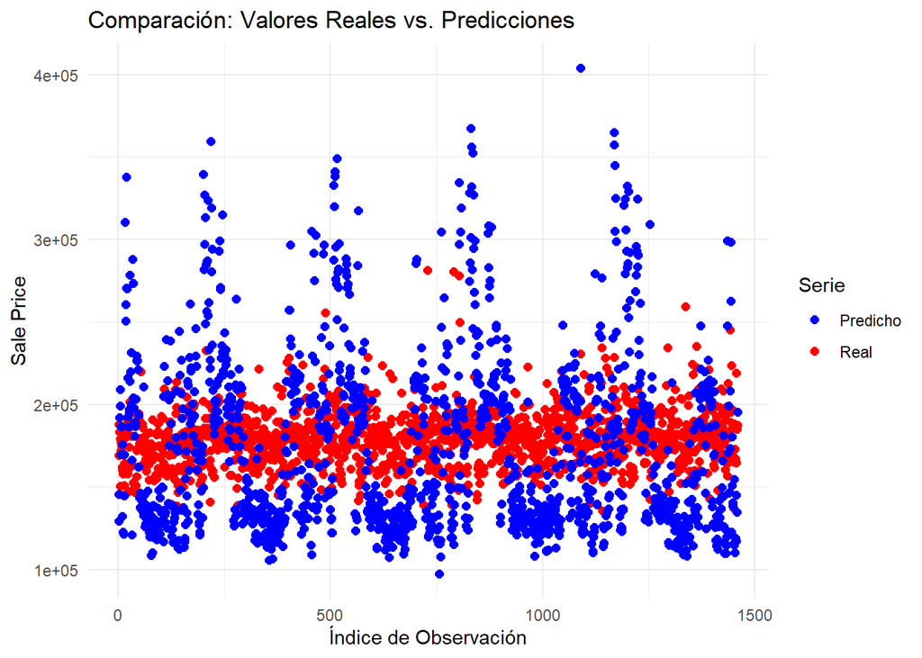

```r
# Crear un dataframe con los valores reales y predichos
df_resultados <- data.frame(
  Índice = 1:length(datos$SalePrice),  # Índice de cada observación
  Real = datos$SalePrice,
  Predicho = predModelo1
)

# Graficar ambas series
ggplot(df_resultados) +
  geom_point(aes(x = Índice, y = Real, color = "Real"), size = 2) +  # Puntos rojos (valores reales)
  geom_point(aes(x = Índice, y = Predicho, color = "Predicho"), size = 2) +  # Puntos azules (predicciones)
  scale_color_manual(values = c("Real" = "red", "Predicho" = "blue")) +  # Definir colores
  labs(title = "Comparación: Valores Reales vs. Predicciones",
       x = "Índice de Observación",
       y = "Sale Price",
       color = "Serie") +
  theme_minimal()
```

Se observa en la gráfica que hay algunos puntos que el modelo no pudo predecir aunque no observamos que los datos esten sobreajustados como en los otros modelos vistos anteriormente. Por otro lado en los modelos anteriores se ve que se relaciona con el modelo de random forest.

8. Haga un modelo usando validación cruzada, compare los resultados de este con los del modelo anterior. ¿Cuál funcionó mejor?

```r
trctrl <- trainControl(method = "repeatedcv",
                           number = 10,
                           repeats = 3)
modelo2 <- train(
  SalePrice~.,
  data=train,
  method = "knn",
  trControl = trctrl,
  preProcess= c("center","scale"),
  tuneGrid = parametros
)
predModelo2 <- predict(modelo2, newdata=datos)
```

```r
 RMSE(predModelo2, datos$SalePrice)
```

```
## [1] 52319.64
```

El RMSE es de 52319.64, es el mismo que el modelo de knn utilizado donde k es igual a la raiz cuadrada del numero de filas (38).

En el siguiente gráfico se muestran los valores predichos y los reales.

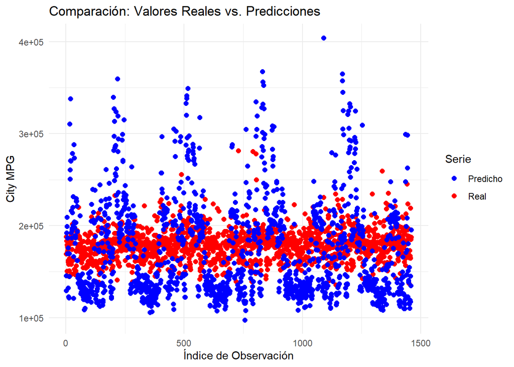

```r
df_resultados <- data.frame(
  Índice = 1:length(datos$SalePrice),  # Índice de cada observación
  Real = datos$SalePrice,
  Predicho = predModelo2
)

# Graficar ambas series
ggplot(df_resultados) +
  geom_point(aes(x = Índice, y = Real, color = "Real"), size = 2) +  # Puntos rojos (valores reales)
  geom_point(aes(x = Índice, y = Predicho, color = "Predicho"), size = 2) +  # Puntos azules (predicciones)
  scale_color_manual(values = c("Real" = "red", "Predicho" = "blue")) +  # Definir colores
  labs(title = "Comparación: Valores Reales vs. Predicciones",
       x = "Índice de Observación",
       y = "City MPG",
       color = "Serie") +
  theme_minimal()
```

Observamos que no tiene sobreajustes de datos y además observamos que con validación cruzada, tiene casi los mismos datos predichos que en la gráfica del modelo anterior. Ahora con la eficiencia del algoritmo se podría observar si es mejor el modelo con o sin validación cruzada.

9. Tanto para los modelos de regresión como de clasificación, pruebe con varios valores de los hiperparámetros ¿Qué parámetros pueden tunearse en un KNN?, use el mejor modelo del tuneo, ¿Mejoraron los resultados usando el mejor modelo ahora? Explique

Se puede realizar el cambio de valor K, necesita tener validación cruzada e incluso preprocesar los datos.

Tuneando varios valores de k

```r
parametros <- expand.grid(k = seq(1,25))
modelo3 <- train(
  SalePrice~.,
  data=train,
  method = "knn",
  trControl = trctrl,
  preProcess= c("center","scale"),
  tuneGrid = parametros
)
predModelo3 <- predict(modelo3, newdata=datos)
```

El mejor valor de k

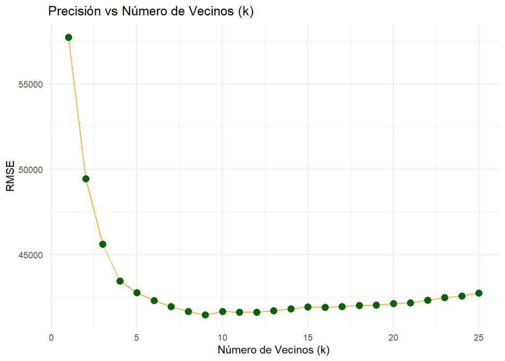

```r
ggplot(modelo3$results, aes(x = k, y = RMSE)) +
  geom_line(color = "orange") +  # Línea azul
  geom_point(size = 3, color = "darkgreen") +  # Puntos rojos
  labs(title = "Precisión vs Número de Vecinos (k)",
       x = "Número de Vecinos (k)",
       y = "RMSE") +
  theme_minimal()  # Tema limpio
```

Se observa que el mejor vecino de acuerdo con la gráfica es 9 u 11.

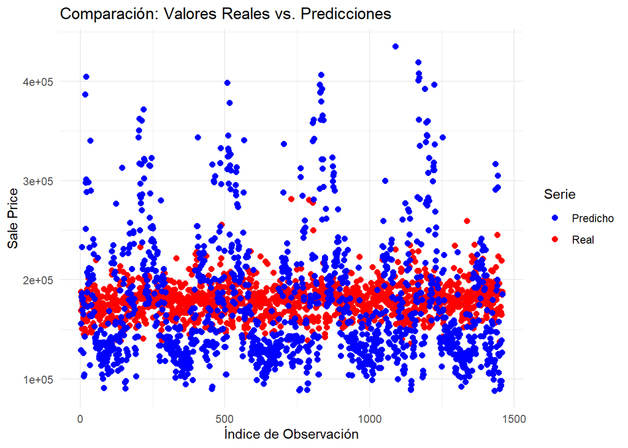

```r
df_resultados <- data.frame(
  Índice = 1:length(datos$SalePrice),  # Índice de cada observación
  Real = datos$SalePrice,
  Predicho = predModelo3
)

# Graficar ambas series
ggplot(df_resultados) +
  geom_point(aes(x = Índice, y = Real, color = "Real"), size = 2) +  # Puntos rojos (valores reales)
  geom_point(aes(x = Índice, y = Predicho, color = "Predicho"), size = 2) +  # Puntos azules (predicciones)
  scale_color_manual(values = c("Real" = "red", "Predicho" = "blue")) +  # Definir colores
  labs(title = "Comparación: Valores Reales vs. Predicciones",
       x = "Índice de Observación",
       y = "Sale Price",
       color = "Serie") +
  theme_minimal()
```

```r
rmse <- RMSE(predModelo3, datos$SalePrice)
rmse
```

```
## [1] 60844.42
```

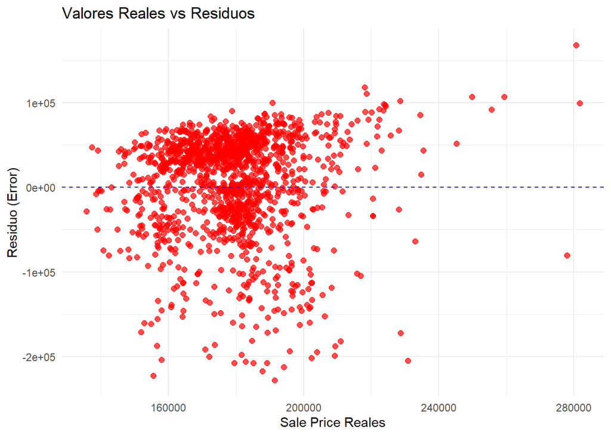

```r
residuos <- datos$SalePrice - predModelo3

# Crear un dataframe con los valores reales y residuos
df_resultados <- data.frame(
  Real = datos$SalePrice,
  Residuo = residuos
)

# Graficar valores reales vs residuos
ggplot(df_resultados, aes(x = Real, y = Residuo)) +
  geom_point(color = "red", size = 2, alpha = 0.7) +  # Puntos rojos
  geom_hline(yintercept = 0, linetype = "dashed", color = "blue") +  # Línea en y = 0
  labs(title = "Valores Reales vs Residuos",
       x = "Sale Price Reales",
       y = "Residuo (Error)") +
  theme_minimal()
```

Se observa que la dispersión de los puntos rojos no es uniforme a lo largo del eje X. En la zona de precios de venta más bajos ( 160,000 - 200,000), los residuos tienden a ser más dispersos, mientras que en la zona de precios más altos, la dispersión es menor. Por lo cual se puede inferir que el modelo tiene una varianza de error no constante.

10. Compare la eficiencia del algoritmo con el resultado obtenido con el árbol de decisión (el de clasificación), el modelo de random forest y el de naive bayes que hizo en las entregas pasadas. ¿Cuál es mejor para predecir? ¿Cuál se demoró más en procesar?

Eficiencia del modelo donde se utiliza la raiz cuadrada de filas donde es 38

```r
parametros <- expand.grid(k = k_vecinos)
system.time({
  modelo1 <- train(
  SalePrice~.,
  data=train,
  method = "knn",
  preProcess= c("center","scale","knnImpute"),
  tuneGrid = parametros
)
})
```

```
##    user  system elapsed
##    9.30    0.39    9.81
```

Eficiencia del modelo utilizado con validación cruzada

```r
trctrl <- trainControl(method = "repeatedcv",
                           number = 10,
                           repeats = 3)
system.time({
modelo2 <- train(
  SalePrice~.,
  data=train,
  method = "knn",
  trControl = trctrl,
  preProcess= c("center","scale"),
  tuneGrid = parametros
)
})
```

```
##    user  system elapsed
##    4.23    0.37    4.72
```

Eficiencia del modelo utilizando diferentes hiperpárametros

```r
parametros <- expand.grid(k = seq(1,25))
system.time({
modelo3 <- train(
  SalePrice~.,
  data=train,
  method = "knn",
  trControl = trctrl,
  preProcess= c("center","scale"),
  tuneGrid = parametros
)
})
```

```
##    user  system elapsed
##  155.92   12.27  172.14
```